# Disciplina - DQF10441 Física Experimental II"

## Aula em 16/07/2021 - Semestre 2021/1 EARTE

### [DQF - CCENS](http://alegre.ufes.br/ccens/departamento-de-quimica-e-fisica) - [UFES/Alegre](http://alegre.ufes.br/)

#### Professor : [Roberto Colistete Jr.](https://github.com/rcolistete)

## TAREFA PASSADA

Tarefa passada na aula anterior, individual ou 2 alunas/os, para mostrar na aula de hoje :

- experimentar ao menos 1 dos 3 softwares webapp de simulação de circuitos elétricos/eletrônicos citados na aula ([Falstad](https://www.falstad.com/circuit/circuitjs.html), [CircuitLab](https://www.circuitlab.com/), [PartSim](https://www.partsim.com/));
- montar um circuito simples com fonte de tensão e um circuito com 3 resistores : 1 em série com 2 outros em paralelo;
- opinar sobre facilidade ou dificuldade de usar o software webapp escolhido.

Alguém fez ? Mostre o que fez.

Um(a) aluno/a mostrou uso do CircuitLab com fonte + 3 R's, faltando registrar conta para continuar o uso.

# Softwares de Simulação de Circuitos Elétricos/Eletrônicos

Foram apresentados na aula anterior as seguintes web-apps (acessíveis via navegador web, sem precisar instalar no computador) :

- [Falstad](https://www.falstad.com/circuit/circuitjs.html);
- [CircuitLab](https://www.circuitlab.com/);
- [PartSim](https://www.partsim.com/).

Seguem softwares offline, para instalar em computador.

### [LTSpice](https://www.analog.com/en/design-center/design-tools-and-calculators/ltspice-simulator.html)

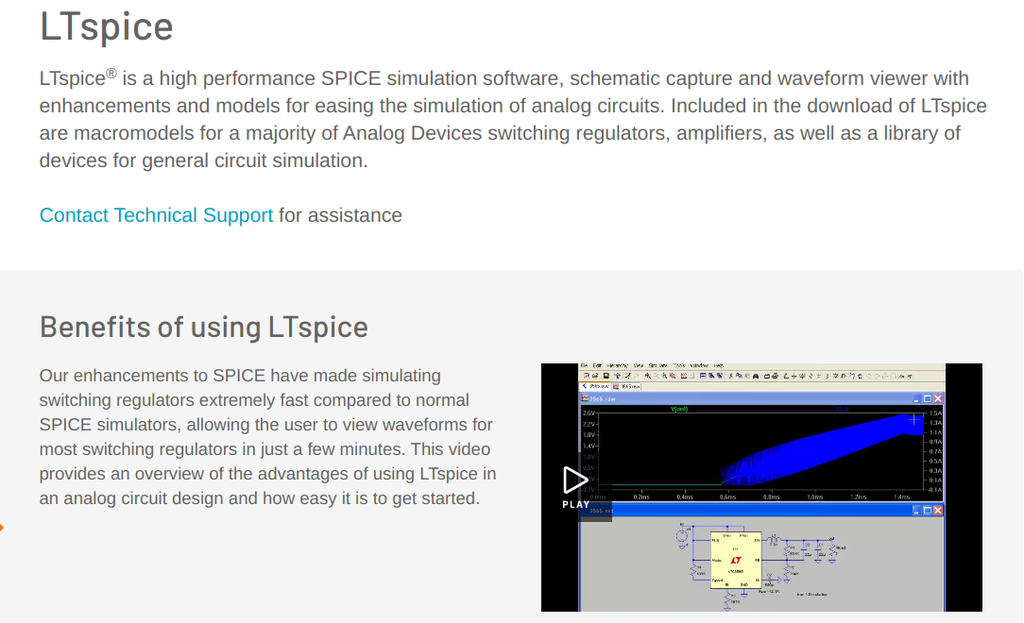

[LTSpice](https://www.analog.com/en/design-center/design-tools-and-calculators/ltspice-simulator.html) é um software gratuito de computador, simulador de circuito eletrônico analógico baseado em [SPICE](http://bwrcs.eecs.berkeley.edu/Classes/IcBook/SPICE/), produzido pelo fabricante de semicondutores [Analog Devices](https://www.analog.com/en/index.html).

[SPICE](http://bwrcs.eecs.berkeley.edu/Classes/IcBook/SPICE/) é o software mais amplamente distribuído e usado na indústria para simulação de circuitos eletrônicos, sendo referência mundial.

LTSpice em versões gratuitas para Mac OS e Windows. No Linux, LTSpice roda via WINE (Wine Is Not an Emulator).

LTSpice tem muitos recursos, exemplos e tutoriais, devido ao suporte oficial da Analog Devices e herança do SPICE. Porém é mais complexo de aprender.

Matérias e tutoriais, alguns em português :

- [Primeiros passos com o LTSpice XVII](https://www.embarcados.com.br/primeiros-passos-com-o-ltspice-xvii/);
- [IoT e LTSpice, uma boa combinação](https://www.embarcados.com.br/iot-e-ltspice-uma-boa-combinacao/);
- [LTSpice: Primeiros Passos](https://portal.vidadesilicio.com.br/ltspice-primeiros-passos/);
- [PDF da USP de 53 páginas, "Manual prático do LTspice IV"](https://edisciplinas.usp.br/pluginfile.php/4875263/mod_folder/content/0/Manual%20LTSpice%20-%20Rev%208%20-%20Leandro%20do%20Nascimento.pdf?forcedownload=1);
- [LTspice Tutorials - SimonBramble](http://www.simonbramble.co.uk/lt_spice/ltspice_lt_spice.htm);
- [Getting Started with LTspice - Sparkfun](https://learn.sparkfun.com/tutorials/getting-started-with-ltspice/);

Mais softwares de simulação e projeto de circuitos elétricos/eletrônicos

- [Best Free electronics Circuit Simulation Software](https://microcontrollerslab.com/circuit-simulation-software-free/);
- [Electronic circuit design and simulation software list](http://www.circuitstoday.com/circuit-design-and-simulation-softwares).

# Softwares (EDA) de Projeto de Circuitos Elétricos/Eletrônicos

Softwares de projeto de circuitos elétricos/eletrônicos são chamados de **EDA (Electronic Design Automation)**.

Permitem projetar/desenhar circuitos elétricos/eletrônicos, placas de circuito impresso, etc.

Lista de softwares EDA, inclusive gratuitos :

- [Comparison of EDA software - Wikipedia](https://en.wikipedia.org/wiki/Comparison_of_EDA_software);
- [9 Free And Open Source Software For Circuit Designing - Electronics.foru](https://www.electronicsforu.com/resources/cool-stuff-misc/open-source-circuit-design-software);
- [8 Best Free Electronic Design Automation Tools - LinuxLinks](https://www.linuxlinks.com/eda/);
- [Tools Review: The 10 Best FREE PCB Design Solutions - Bittele Electronics](https://www.7pcb.com/blog/best-pcb-design-solutions.php);
- [Review of the Top Free Electronics Design Automation Software - AllAboutCircuits](https://www.allaboutcircuits.com/news/review-of-the-top-free-electronics-design-automation-software/).

### [Fritzing](https://fritzing.org/download/)

[figure not shown]

[Fritzing](https://fritzing.org/download/) é um software de [código-fonte aberto](https://github.com/fritzing/) e gratuito de computador para EDA (Electronic Design Automation), sendo muito amigável e popular. **Tem modo protoboard que é muito fácil de usar**, só arrastar os componentes, com uma biblioteca gigantesca. E a interface tem versão em português (pt-br).

Embora para o download seja pedida doação (EUR8/25), Fritzing é gratuito e disponível para Linux, Mac OS e Windows. Alguns repositórios Linux tem Fritzing disponível, com fácil instalação :

- [Hardware open source: instale o editor Fritzing no Ubuntu - Blog do Edivaldo Brito](https://www.edivaldobrito.com.br/hardware-open-source-instale-o-editor-fritzing-ubuntu/);
- [no Manjaro/Arch a última versão está disponível em repositórios da comunidade (AUR)](https://aur.archlinux.org/packages/fritzing/).

Tutoriais, documentação, etc, sobre Fritzing :

- [oficiais no site Fritzing](https://fritzing.org/learning/);
- [Fritzing Tutorials - instructables](https://www.instructables.com/id/Fritzing-Tutorials/);
- [muitos tutoriais em vídeo no YouTube](https://www.youtube.com/results?search_query=Fritzing), inclusive em português;
- no blog FilipeFlop, em português, tem 3 tutoriais, [Introdução ao Fritzing](https://www.filipeflop.com/blog/introducao-ao-fritzing/), [Criação de Fritzing Part – Parte 1](https://www.filipeflop.com/blog/criacao-de-fritzing-part-parte-1/) e [Criação de Fritzing Part – Parte 2](https://www.filipeflop.com/blog/criar-componente-fritzing-parte-2/);
- [O que é Fritzing? - SempreUpdate](https://sempreupdate.com.br/o-que-e-fritzing/), em português;
- [Tutorial Fritzing – Parte I](https://www.robtronics.com.br/eaduino/2013/07/tutorial-fritzing-parte-i/), em português.

Fritzing é muito usado em sites/blogs de "makers" ("fazedores" de circuitos eletrônicos, etc), como o :

- [Instructables](https://www.instructables.com/);
- [Hackaday](https://hackaday.io/projects)
- [Hackster](https://www.hackster.io/projects?ref=topnav);
- [MakerShare](https://makershare.com/projects).

### [KiCAD](https://www.kicad.org/)

[figure not shown]

KiCAD é um software gratuito de computador para EDA (Electronic Design Automation), sendo profissional com muitos recursos e muito popular.

[KiCAD é gratuito e disponível para Linux, Mac OS e Windows](https://www.kicad.org/download/).

KiCAD tem muita documentação oficial e da comunidade, bem como tutoriais, etc.

### [EasyEDA](https://easyeda.com/)

[figure not shown]

EasyEDA é outro software gratuito de computador para EDA (Electronic Design Automation), sendo competidor do KiCAD, bastante elogiado e mais simples de usar que KiCAD.

**EasyEDA tem versão online (web-app)** e offline (para PC desktop), gratuita porém com propaganda, vide [versão gratuita](https://easyeda.com/page/pricing).

Tem [download p/ Mac OS, Linux e Windows](https://easyeda.com/page/download). Alguns Linux tem EasyEDA no repositório, por exemplo em [Linux Arch/Manjaro, no repositório AUR](https://aur.archlinux.org/packages/easyeda-bin/).

## TAREFA

Para próxima aula em 23/07/2021, individual ou 2 alunas/os :

- experimentar ao menos 1 dos 3 softwares de desenho/projetosimulação de circuitos eletrônicos citados acima;
- montar um circuito simples com fonte de tensão e um circuito com 3 resistores : 1 em série com 2 outros em paralelo;
- opinar sobre facilidade ou dificuldade de usar o software escolhido.

# Mudanças no repositório de "Física Experimental II"

- Média agora tem "Média de PArticipação (MPA)";
- Experimentos revisados;
- Cronograma :
  - (30/07) 1o roteiro "Caracterização de dispositivos eletrônicos via multímetros";
  - (06/08) 2o roteiro, "Ligação série e paralelo";
  - (13/08) 3o roteiro, "Circuitos RC, carga e descarga de capacitor";
  - (20/08) 4o roteiro, "Filtros RC e espectro de sinal usando osciloscópio";
  - (03/09) 5o roteiro, "Medição de campo magnético";
  - (17/09) 6o roteiro, "Medição de luz e espectro luminoso".

# Multímetros

[figure not shown]

[Minipa](https://www.minipa.com.br/categoria/1/multimetros), uma das fabricantes brasileiras de multímetros analógicos e digitais.

## Lendo medidas de um Multímetro

Em parte das medidas usaremos o multímetro Minipa [ET-2042E](https://www.minipa.com.br/multimetros/multimetros-digitais/349-et-2042e)

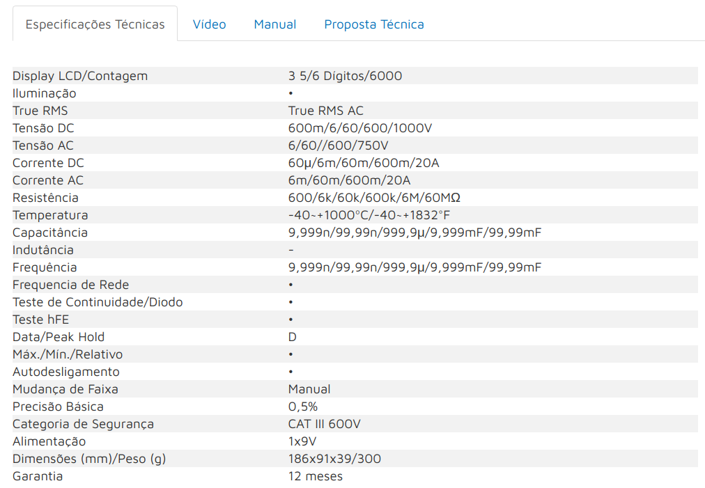

### Como ler medidas de tensão $V$ de um voltímetro (ou multímetro nesse modo)

Quantos já sabem ? Uns 5-6.

Para medir :

- Vbat = 1,5 V (teórico);

Qual escala do multímetro Minipa ET-2042E deve ser usada para ter menor erro em tal medida ?

R.: Escala do voltímetro ?

Vide tabela B do manual do multímetro Minipa ET-2042E, escala de 6V, que tem resolução de 0,001V e precisão de ±(0,5%+2D).

Se em tal escala foi medida a tensão (elétrica) de uma pilha recarregável, $Vbat = 1,329 V$, então calcule a incerteza do Vbat medido, escrevendo a medida no formato (valor nominal +/- incerteza) com o número correto de algarismos significativos.

### Como ler medidas de corrente elétrica $i$ de um amperímetro (ou multímetro nesse modo)

Quantos já sabem ? Uns 5-6.

### Como ler medidas de resistência elétrica $R$ de um ohmímetro (ou multímetro nesse modo)

Quantos já sabem ? Uns 5-6.

Para medir :

- R = 470 Ohm (valor nominal de um resistor);

Qual escala do multímetro Minipa ET-2042E deve ser usada para ter menor erro em tal medida ?

(Continua na aula seguinte)